# Court Curb Analysis

### Up until 2012 data (problems with ideology)

Getting data without the other years

```r
count_data2 <- gavelCultureControl %>%
  filter(!(Year %in% c("2007", "43147", "2013", "2014", "2015", "2016", "2017", "2018"))) %>% # filtering out bad data
  group_by(State, Year) %>%
  mutate(curbs = sum(curbing)) %>%
  distinct(State, Year, .keep_all = TRUE) %>%
  arrange(State, Year)

count_data2
```

```
## # A tibble: 235 x 38
## # Groups:   State, Year [235]
##    Fullstate State Type  `Bill Number`  Year Elected MoreDefined
##    <chr>     <chr> <chr> <chr>         <dbl> <chr>   <chr>
##  1 Alaska    AK    Other HB 411         2008 Elected Retention
##  2 Alaska    AK    Sala… SB 30          2009 Elected Retention
##  3 Alaska    AK    Sala… SB 30          2010 Elected Retention
##  4 Alaska    AK    Juri… HB 88          2011 Elected Retention
##  5 Alaska    AK    Sala… HB 299         2012 Elected Retention
##  6 Alabama   AL    Juri… HB 28          2008 Elected Partisan
##  7 Alabama   AL    Sele… HB 126         2009 Elected Partisan
##  8 Alabama   AL    Sele… HB 1 (Specia…  2010 Elected Partisan
##  9 Alabama   AL    Other HB 155         2011 Elected Partisan
## 10 Alabama   AL    Rule… HB 14          2012 Elected Partisan
## # ... with 225 more rows, and 31 more variables: Description <chr>, `Last
## #   Action` <chr>, curbing <dbl>, RichardLastAction <chr>, `Richard
## #   Description` <chr>, `Date Signed` <dttm>, Unsure <dbl>, `Very
## #   interesting` <chr>, Notes <lgl>, election <chr>, judicial <dbl>,
## #   governor <dbl>, lower <dbl>, upper <dbl>, less <dbl>, more <dbl>,
## #   outside <dbl>, how_much_less <dbl>, how_much_more <dbl>,
## #   distance_closest_branch <dbl>, Moralistic <dbl>,
## #   Traditionalistic <dbl>, RepublicanLegslature <dbl>,
## #   SplitLegislature <dbl>, Culture <chr>, legislativeControl <chr>,
## #   unified <dbl>, court_gov_dist <dbl>, court_lower_dist <dbl>,
## #   court_upper_dist <dbl>, curbs <dbl>
```

Adding in new variables

```r
count_data2$elected <- ifelse(count_data2$Elected == "Elected", 1, 0)
count_data2$partisan <- ifelse(count_data2$MoreDefined == "Partisan", 1, 0)
count_data2$nonpartisan <- ifelse(count_data2$MoreDefined == "Nonpartisan", 1, 0)
count_data2$retention <- ifelse(count_data2$MoreDefined == "Retention", 1, 0)

count_data2$elected_ideology_gov <- count_data2$elected * count_data2$court_gov_dist
count_data2$elected_ideology_upper <- count_data2$elected * count_data2$court_upper_dist
count_data2$elected_ideology_lower <- count_data2$elected * count_data2$court_lower_dist

count_data2$partisan_ideology_gov <- count_data2$partisan * count_data2$court_gov_dist
count_data2$partisan_ideology_upper <- count_data2$partisan * count_data2$court_upper_dist
count_data2$partisan_ideology_lower <- count_data2$partisan * count_data2$court_lower_dist

count_data2$nonpartisan_ideology_gov <- count_data2$nonpartisan * count_data2$court_gov_dist
count_data2$nonpartisan_ideology_upper <- count_data2$nonpartisan * count_data2$court_upper_dist
count_data2$nonpartisan_ideology_lower <- count_data2$nonpartisan * count_data2$court_lower_dist

count_data2$retention_ideology_gov <- count_data2$retention * count_data2$court_gov_dist
count_data2$retention_ideology_upper <- count_data2$retention * count_data2$court_upper_dist
count_data2$retention_ideology_lower <- count_data2$retention * count_data2$court_lower_dist

count_data2 <- left_join(count_data2, professionalization, by = c("Fullstate" = "State"))

table(count_data2$Year, count_data2$Fullstate)
```

```
##
##        Alabama Alaska Arizona Arkansas California Colorado Connecticut
##   2008       1      1       1        0          1        1           1
##   2009       1      1       1        1          1        1           1
##   2010       1      1       1        0          1        1           1
##   2011       1      1       1        1          1        1           1
##   2012       1      1       1        0          1        1           1
##
##        Delaware Florida Georgia Hawaii Idaho Illinois Indiana Iowa Kansas
##   2008        1       1       1      1     1        1       1    1      1
##   2009        1       1       1      1     1        1       1    1      1
##   2010        1       1       1      1     1        1       1    1      1
##   2011        1       1       1      1     1        1       1    1      1
##   2012        1       1       1      1     1        1       1    1      1
##
```

[output cut: 41 more lines]

```r
curbs_2.nb <- glm.nb(curbs ~ retention + partisan + nonpartisan,
                     data = count_data2)
summary(curbs_2.nb) # nothing significant
```

```
##
## Call:
## glm.nb(formula = curbs ~ retention + partisan + nonpartisan,
##     data = count_data2, init.theta = 0.8138895666, link = log)
##
## Deviance Residuals:
##     Min       1Q   Median       3Q      Max
## -1.7258  -1.5762  -0.2824   0.3691   1.9418
##
## Coefficients:
##             Estimate Std. Error z value Pr(>|z|)
## (Intercept)   1.1967     0.1668   7.173 7.35e-13 ***
## retention     0.1813     0.2104   0.861    0.389
## partisan      0.2521     0.2739   0.920    0.357
## nonpartisan  -0.1213     0.2343  -0.518    0.605
## ---
## Signif. codes:  0 '***' 0.001 '**' 0.01 '*' 0.05 '.' 0.1 ' ' 1
##
## (Dispersion parameter for Negative Binomial(0.8139) family taken to be 1)
##
##     Null deviance: 264.47  on 233  degrees of freedom
## Residual deviance: 261.52  on 230  degrees of freedom
##   (1 observation deleted due to missingness)
## AIC: 1130.4
##
## Number of Fisher Scoring iterations: 1
##
##
##               Theta:  0.814
##           Std. Err.:  0.104
##
##  2 x log-likelihood:  -1120.434
```

```r
curbs2.elected1.nb <- glm.nb(curbs ~ elected + court_upper_dist + court_lower_dist,
                     data = count_data2)
summary(curbs2.elected1.nb) # upper distance is again distinct
```

```
##
## Call:
## glm.nb(formula = curbs ~ elected + court_upper_dist + court_lower_dist,
##     data = count_data2, init.theta = 0.8696261942, link = log)
##
## Deviance Residuals:
##     Min       1Q   Median       3Q      Max
## -1.8996  -1.5714  -0.2956   0.3737   2.1997
##
## Coefficients:
##                  Estimate Std. Error z value Pr(>|z|)
## (Intercept)       0.94111    0.19117   4.923 8.52e-07 ***
## elected           0.04656    0.18638   0.250   0.8027
## court_upper_dist  0.63994    0.32612   1.962   0.0497 *
## court_lower_dist  0.02038    0.32572   0.063   0.9501
## ---
## Signif. codes:  0 '***' 0.001 '**' 0.01 '*' 0.05 '.' 0.1 ' ' 1
##
## (Dispersion parameter for Negative Binomial(0.8696) family taken to be 1)
##
##     Null deviance: 268.73  on 228  degrees of freedom
## Residual deviance: 257.60  on 225  degrees of freedom
##   (6 observations deleted due to missingness)
## AIC: 1105.2
##
## Number of Fisher Scoring iterations: 1
##
##
##               Theta:  0.870
##           Std. Err.:  0.115
##
##  2 x log-likelihood:  -1095.151
```

```r
curbs2.elected2.nb <- glm.nb(curbs ~ elected + court_upper_dist + court_lower_dist + elected_ideology_lower + elected_ideology_upper,
                     data = count_data2)
summary(curbs2.elected2.nb) # nothing significant
```

```
##
## Call:
## glm.nb(formula = curbs ~ elected + court_upper_dist + court_lower_dist +
##     elected_ideology_lower + elected_ideology_upper, data = count_data2,
##     init.theta = 0.8829737097, link = log)
##
## Deviance Residuals:
##     Min       1Q   Median       3Q      Max
## -1.9368  -1.5397  -0.3348   0.3723   2.3338
##
## Coefficients:
##                        Estimate Std. Error z value Pr(>|z|)
## (Intercept)              1.1236     0.2477   4.535 5.75e-06 ***
## elected                 -0.2345     0.2929  -0.801    0.423
## court_upper_dist        -0.1200     1.0624  -0.113    0.910
## court_lower_dist         0.2693     0.9648   0.279    0.780
## elected_ideology_lower  -0.1455     1.0267  -0.142    0.887
## elected_ideology_upper   0.8608     1.1156   0.772    0.440
## ---
## Signif. codes:  0 '***' 0.001 '**' 0.01 '*' 0.05 '.' 0.1 ' ' 1
##
## (Dispersion parameter for Negative Binomial(0.883) family taken to be 1)
##
##     Null deviance: 271.26  on 228  degrees of freedom
## Residual deviance: 257.73  on 223  degrees of freedom
##   (6 observations deleted due to missingness)
## AIC: 1106.9
##
## Number of Fisher Scoring iterations: 1
##
##
##               Theta:  0.883
##           Std. Err.:  0.117
##
##  2 x log-likelihood:  -1092.908
```

```r
curbs2.elected3.nb <- glm.nb(curbs ~ elected + court_upper_dist + court_lower_dist + elected_ideology_lower + elected_ideology_upper + Moralistic + Traditionalistic + RepublicanLegslature + SplitLegislature +  Professionalization,
                     data = count_data2)
summary(curbs2.elected3.nb)
```

```
##
## Call:
## glm.nb(formula = curbs ~ elected + court_upper_dist + court_lower_dist +
##     elected_ideology_lower + elected_ideology_upper + Moralistic +
##     Traditionalistic + RepublicanLegslature + SplitLegislature +
##     Professionalization, data = count_data2, init.theta = 1.094906677,
##     link = log)
##
## Deviance Residuals:
##     Min       1Q   Median       3Q      Max
## -2.0737  -1.3195  -0.3526   0.3829   1.9432
##
## Coefficients:
##                        Estimate Std. Error z value Pr(>|z|)
## (Intercept)            -0.63315    0.39823  -1.590  0.11185
## elected                -0.20032    0.29230  -0.685  0.49315
## court_upper_dist        0.16278    1.09803   0.148  0.88215
## court_lower_dist        0.54509    1.00181   0.544  0.58637
## elected_ideology_lower  0.09200    1.06644   0.086  0.93125
## elected_ideology_upper  0.44317    1.15193   0.385  0.70045
## Moralistic             -0.23506    0.19829  -1.185  0.23584
## Traditionalistic        0.42691    0.24245   1.761  0.07827 .
## RepublicanLegslature    0.13220    0.22465   0.588  0.55621
## SplitLegislature       -0.70371    0.24615  -2.859  0.00425 **
## Professionalization     0.48251    0.09086   5.310 1.09e-07 ***
## ---
## Signif. codes:  0 '***' 0.001 '**' 0.01 '*' 0.05 '.' 0.1 ' ' 1
##
## (Dispersion parameter for Negative Binomial(1.0949) family taken to be 1)
##
##     Null deviance: 307.80  on 223  degrees of freedom
## Residual deviance: 253.87  on 213  degrees of freedom
##   (11 observations deleted due to missingness)
## AIC: 1056
##
## Number of Fisher Scoring iterations: 1
##
##
##               Theta:  1.095
##           Std. Err.:  0.161
##
##  2 x log-likelihood:  -1031.984
```

```r
curbs2_full.nb <- glm.nb(curbs ~ Moralistic + Traditionalistic + RepublicanLegslature + SplitLegislature + court_lower_dist + court_upper_dist + retention + partisan + nonpartisan + partisan_ideology_upper + partisan_ideology_lower + nonpartisan_ideology_upper + nonpartisan_ideology_lower + retention_ideology_lower + retention_ideology_upper + Professionalization,
                     data = count_data2)
summary(curbs2_full.nb) # none of my important variables are predictive
```

```
##
## Call:
## glm.nb(formula = curbs ~ Moralistic + Traditionalistic + RepublicanLegslature +
##     SplitLegislature + court_lower_dist + court_upper_dist +
##     retention + partisan + nonpartisan + partisan_ideology_upper +
##     partisan_ideology_lower + nonpartisan_ideology_upper + nonpartisan_ideology_lower +
##     retention_ideology_lower + retention_ideology_upper + Professionalization,
##     data = count_data2, init.theta = 1.219082008, link = log)
##
## Deviance Residuals:
##     Min       1Q   Median       3Q      Max
## -2.2126  -1.3372  -0.2817   0.4882   1.8858
##
## Coefficients:
##                            Estimate Std. Error z value Pr(>|z|)
## (Intercept)                -0.74460    0.39571  -1.882  0.05988 .
## Moralistic                 -0.20085    0.19923  -1.008  0.31339
## Traditionalistic            0.41529    0.23542   1.764  0.07772 .
## RepublicanLegslature        0.24845    0.24270   1.024  0.30598
## SplitLegislature           -0.83015    0.26213  -3.167  0.00154 **
## court_lower_dist            0.53024    0.98330   0.539  0.58972
## court_upper_dist            0.21355    1.07604   0.198  0.84269
## retention                  -0.50217    0.32217  -1.559  0.11907
## partisan                    0.46171    0.43403   1.064  0.28743
## nonpartisan                -0.07176    0.38354  -0.187  0.85158
## partisan_ideology_upper    -2.00733    1.78125  -1.127  0.25977
## partisan_ideology_lower     1.07006    1.70869   0.626  0.53115
## nonpartisan_ideology_upper -0.47325    1.18772  -0.398  0.69030
## nonpartisan_ideology_lower  0.71334    1.09392   0.652  0.51434
## retention_ideology_lower   -0.53807    1.15915  -0.464  0.64251
## retention_ideology_upper    1.35773    1.18540   1.145  0.25205
## Professionalization         0.50764    0.09141   5.553  2.8e-08 ***
## ---
## Signif. codes:  0 '***' 0.001 '**' 0.01 '*' 0.05 '.' 0.1 ' ' 1
##
## (Dispersion parameter for Negative Binomial(1.2191) family taken to be 1)
##
##     Null deviance: 327.54  on 223  degrees of freedom
## Residual deviance: 254.14  on 207  degrees of freedom
##   (11 observations deleted due to missingness)
## AIC: 1053.5
##
## Number of Fisher Scoring iterations: 1
##
##
##               Theta:  1.219
##           Std. Err.:  0.185
## Warning while fitting theta: alternation limit reached
##
##  2 x log-likelihood:  -1017.495
```

# Post-Steigerwalt Meeting (End of November 2018)

Suggestions from Steigerwalt:

- What percentage of all legislation that year that deal with courts are court curbing bills (4 court curbing out of 20 bills)? Run a regression with that
- Do unified/divided instead of the republican/democratic/split
- map out upper and partisan interaction (plot it out). This applies, right now, to the count models
- Question: is the full model overfitted?

## Doing Unified government

Full model

```r
curbs_unified.nb <- glm.nb(curbs ~ Moralistic + Traditionalistic + unified + court_lower_dist + court_upper_dist + elected + elected_ideology_upper + elected_ideology_lower + Professionalization,
                     data = count_data2)

summary(curbs_unified.nb) # traditionalistic, professionalization, and unified are significant and positive.
```

```
##
## Call:
## glm.nb(formula = curbs ~ Moralistic + Traditionalistic + unified +
##     court_lower_dist + court_upper_dist + elected + elected_ideology_upper +
##     elected_ideology_lower + Professionalization, data = count_data2,
##     init.theta = 1.087453977, link = log)
##
## Deviance Residuals:
##     Min       1Q   Median       3Q      Max
## -2.0797  -1.3127  -0.3492   0.3580   2.0102
##
## Coefficients:
##                        Estimate Std. Error z value Pr(>|z|)
## (Intercept)            -1.36864    0.49448  -2.768  0.00564 **
## Moralistic             -0.25075    0.19791  -1.267  0.20516
## Traditionalistic        0.49732    0.21404   2.323  0.02016 *
## unified                 0.75504    0.23891   3.160  0.00158 **
## court_lower_dist        0.51778    1.00537   0.515  0.60654
## court_upper_dist        0.17917    1.10239   0.163  0.87089
## elected                -0.21277    0.29289  -0.726  0.46756
## elected_ideology_upper  0.44469    1.15615   0.385  0.70051
## elected_ideology_lower  0.14792    1.06841   0.138  0.88989
## Professionalization     0.48340    0.09061   5.335 9.57e-08 ***
## ---
## Signif. codes:  0 '***' 0.001 '**' 0.01 '*' 0.05 '.' 0.1 ' ' 1
##
## (Dispersion parameter for Negative Binomial(1.0875) family taken to be 1)
##
##     Null deviance: 306.57  on 223  degrees of freedom
## Residual deviance: 253.27  on 214  degrees of freedom
##   (11 observations deleted due to missingness)
## AIC: 1054.3
##
## Number of Fisher Scoring iterations: 1
##
##
##               Theta:  1.087
##           Std. Err.:  0.159
##
##  2 x log-likelihood:  -1032.335
```

## Percentage of all legislation that year

```r
percent_curbing <- gavelCultureControl %>%
  group_by(Fullstate, Year) %>%
  summarise(percentage = sum(curbing)/n())

percent_curbing <- percent_curbing %>%
  left_join(count_data, by = c("Fullstate", "Year")) %>%
  dplyr::select(-5:-6, -9:-17)

percent_curbing
```

```
## # A tibble: 482 x 45
## # Groups:   Fullstate [50]
##    Fullstate  Year percentage State Elected MoreDefined election judicial
##    <chr>     <dbl>      <dbl> <chr> <chr>   <chr>       <chr>       <dbl>
##  1 Alabama    2008      0.333 AL    Elected Partisan    AL2008      0.704
##  2 Alabama    2009      0.526 AL    Elected Partisan    AL2009      0.682
##  3 Alabama    2010      0.364 AL    Elected Partisan    AL2010      0.704
##  4 Alabama    2011      0.357 AL    Elected Partisan    AL2011      0.758
##  5 Alabama    2012      0.531 AL    Elected Partisan    AL2012      0.788
##  6 Alabama    2013      0.476 AL    Elected Partisan    AL2013      0.788
##  7 Alabama    2014      0.476 AL    Elected Partisan    AL2014      0.788
##  8 Alabama    2015      0.5   AL    Elected Partisan    AL2015      0.788
##  9 Alabama    2016      0.455 AL    Elected Partisan    AL2016      0.788
## 10 Alabama    2017      0.611 AL    Elected Partisan    AL2017      0.788
## # ... with 472 more rows, and 37 more variables: governor <dbl>,
## #   lower <dbl>, upper <dbl>, less <dbl>, more <dbl>, outside <dbl>,
## #   how_much_less <dbl>, how_much_more <dbl>,
## #   distance_closest_branch <dbl>, Moralistic <dbl>,
## #   Traditionalistic <dbl>, RepublicanLegslature <dbl>,
## #   SplitLegislature <dbl>, Culture <chr>, legislativeControl <chr>,
## #   unified <dbl>, court_gov_dist <dbl>, court_lower_dist <dbl>,
## #   court_upper_dist <dbl>, curbs <dbl>, elected <dbl>, partisan <dbl>,
## #   nonpartisan <dbl>, retention <dbl>, elected_ideology_gov <dbl>,
## #   elected_ideology_upper <dbl>, elected_ideology_lower <dbl>,
## #   partisan_ideology_gov <dbl>, partisan_ideology_upper <dbl>,
## #   partisan_ideology_lower <dbl>, nonpartisan_ideology_gov <dbl>,
## #   nonpartisan_ideology_upper <dbl>, nonpartisan_ideology_lower <dbl>,
## #   retention_ideology_gov <dbl>, retention_ideology_upper <dbl>,
## #   retention_ideology_lower <dbl>, Professionalization <dbl>
```

One of the first things I notice is that Alaska in 2017 has a score of 1, but that is really only because in 2017 there is only one bill that is dealing with the courts and that is a curbing bill. How should that really be counted? It feels like there should be some kind of weighting measure, but will have to discuss with Steigerwalt.

```r
gavelCultureControl %>%
  filter(Fullstate == "Alaska" & Year == 2017)
```

```
## # A tibble: 1 x 37
##   Fullstate State Type  `Bill Number`  Year Elected MoreDefined Description
##   <chr>     <chr> <chr> <chr>         <dbl> <chr>   <chr>       <chr>
## 1 Alaska    AK    Other HB 251         2017 Elected Retention   "Expands s…
## # ... with 29 more variables: `Last Action` <chr>, curbing <dbl>,
## #   RichardLastAction <chr>, `Richard Description` <chr>, `Date
## #   Signed` <dttm>, Unsure <dbl>, `Very interesting` <chr>, Notes <lgl>,
## #   election <chr>, judicial <dbl>, governor <dbl>, lower <dbl>,
## #   upper <dbl>, less <dbl>, more <dbl>, outside <dbl>,
## #   how_much_less <dbl>, how_much_more <dbl>,
## #   distance_closest_branch <dbl>, Moralistic <dbl>,
## #   Traditionalistic <dbl>, RepublicanLegslature <dbl>,
## #   SplitLegislature <dbl>, Culture <chr>, legislativeControl <chr>,
## #   unified <dbl>, court_gov_dist <dbl>, court_lower_dist <dbl>,
## #   court_upper_dist <dbl>
```

It appears, from the graph below, that there is a slight difference in the means between the two. A simple t-test should show us that.

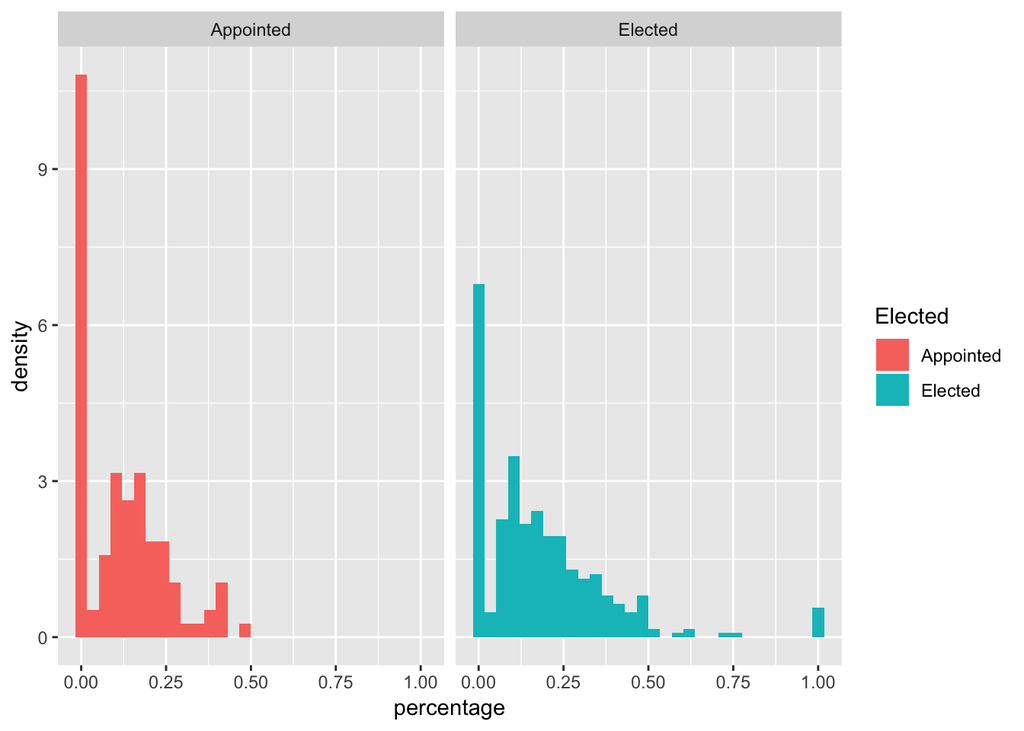

```r
percent_curbing %>%
  filter(!is.na(Elected)) %>%
  ggplot() +
    geom_histogram(aes(percentage, y = ..density.., fill = Elected)) +
    facet_wrap(~ Elected)
```

A simple t-test shows that there is a statistically significant differnece between the two and that the mean of Elected states is significantly higher than the mean of appointed courts.

```r
t.test(percentage ~ Elected, data = percent_curbing)
```

```
##
##  Welch Two Sample t-test
##
## data:  percentage by Elected
## t = -4.3789, df = 284.31, p-value = 1.678e-05
## alternative hypothesis: true difference in means is not equal to 0
## 95 percent confidence interval:
##  -0.09623442 -0.03654784
## sample estimates:
## mean in group Appointed   mean in group Elected
##               0.1174555               0.1838467
```

Now let’s try a simple linear model:

```r
percent_md <- lm(percentage ~ Elected, data = percent_curbing)
summary(percent_md)
```

```
##
## Call:
## lm(formula = percentage ~ Elected, data = percent_curbing)
##
## Residuals:
##      Min       1Q   Median       3Q      Max
## -0.18385 -0.11746 -0.03233  0.07702  0.81615
##
## Coefficients:
##                Estimate Std. Error t value Pr(>|t|)
## (Intercept)     0.11746    0.01663   7.062 5.97e-12 ***
## ElectedElected  0.06639    0.01901   3.493 0.000524 ***
## ---
## Signif. codes:  0 '***' 0.001 '**' 0.01 '*' 0.05 '.' 0.1 ' ' 1
##
## Residual standard error: 0.1744 on 467 degrees of freedom
##   (13 observations deleted due to missingness)
## Multiple R-squared:  0.02546,    Adjusted R-squared:  0.02337
## F-statistic:  12.2 on 1 and 467 DF,  p-value: 0.0005238
```

Now we are starting to get some significance. Let’s start with some more variables and see what happens

```r
percent_md_1 <- lm(percentage ~ elected + court_upper_dist + court_lower_dist,
                    data = percent_curbing)
summary(percent_md_1) # elected is still significant and positive
```

```
##
## Call:
## lm(formula = percentage ~ elected + court_upper_dist + court_lower_dist,
##     data = percent_curbing)
##
## Residuals:
##      Min       1Q   Median       3Q      Max
## -0.19683 -0.11736 -0.03112  0.07635  0.81816
##
## Coefficients:
##                  Estimate Std. Error t value Pr(>|t|)
## (Intercept)      0.111052   0.020073   5.532 5.34e-08 ***
## elected          0.070370   0.019201   3.665 0.000277 ***
## court_upper_dist 0.002077   0.031624   0.066 0.947674
## court_lower_dist 0.010187   0.030728   0.332 0.740403
## ---
## Signif. codes:  0 '***' 0.001 '**' 0.01 '*' 0.05 '.' 0.1 ' ' 1
##
## Residual standard error: 0.1754 on 455 degrees of freedom
##   (23 observations deleted due to missingness)
## Multiple R-squared:  0.02905,    Adjusted R-squared:  0.02265
## F-statistic: 4.538 on 3 and 455 DF,  p-value: 0.003793
```

Adding in interaction terms

```r
percent_md_2 <- lm(percentage ~ elected + court_upper_dist + court_lower_dist + elected_ideology_upper + elected_ideology_lower,
                    data = percent_curbing)

summary(percent_md_2) # elected is still positive and significant.  Nothing else is close
```

```
##
## Call:
## lm(formula = percentage ~ elected + court_upper_dist + court_lower_dist +
##     elected_ideology_upper + elected_ideology_lower, data = percent_curbing)
##
## Residuals:
##      Min       1Q   Median       3Q      Max
## -0.19768 -0.11902 -0.03111  0.07468  0.81874
##
## Coefficients:
##                        Estimate Std. Error t value Pr(>|t|)
## (Intercept)             0.11237    0.02466   4.557  6.7e-06 ***
## elected                 0.06845    0.02946   2.323   0.0206 *
## court_upper_dist       -0.01337    0.09003  -0.149   0.8820
## court_lower_dist        0.02223    0.08295   0.268   0.7888
## elected_ideology_upper  0.01786    0.09631   0.185   0.8530
## elected_ideology_lower -0.01309    0.08971  -0.146   0.8841
## ---
## Signif. codes:  0 '***' 0.001 '**' 0.01 '*' 0.05 '.' 0.1 ' ' 1
##
## Residual standard error: 0.1758 on 453 degrees of freedom
##   (23 observations deleted due to missingness)
## Multiple R-squared:  0.02913,    Adjusted R-squared:  0.01842
## F-statistic: 2.718 on 5 and 453 DF,  p-value: 0.01961
```

Adding in political culture

```r
percent_md_3 <- lm(percentage ~ elected + court_upper_dist + court_lower_dist + elected_ideology_upper + elected_ideology_lower +
                     Moralistic + Traditionalistic,
                    data = percent_curbing)
summary(percent_md_3) # election is still positive and significant.  Nothing else is.
```

```
##
## Call:
## lm(formula = percentage ~ elected + court_upper_dist + court_lower_dist +
##     elected_ideology_upper + elected_ideology_lower + Moralistic +
##     Traditionalistic, data = percent_curbing)
##
## Residuals:
##      Min       1Q   Median       3Q      Max
## -0.20853 -0.11915 -0.02944  0.07349  0.82226
##
## Coefficients:
##                        Estimate Std. Error t value Pr(>|t|)
## (Intercept)             0.11157    0.02545   4.384 1.46e-05 ***
## elected                 0.06370    0.03135   2.032   0.0428 *
## court_upper_dist       -0.01280    0.09050  -0.141   0.8876
## court_lower_dist        0.03355    0.08414   0.399   0.6903
## elected_ideology_upper  0.02416    0.09792   0.247   0.8052
## elected_ideology_lower -0.02670    0.09231  -0.289   0.7726
## Moralistic             -0.01925    0.02216  -0.869   0.3855
## Traditionalistic        0.01699    0.02229   0.762   0.4465
## ---
## Signif. codes:  0 '***' 0.001 '**' 0.01 '*' 0.05 '.' 0.1 ' ' 1
##
## Residual standard error: 0.1763 on 441 degrees of freedom
##   (33 observations deleted due to missingness)
## Multiple R-squared:  0.03222,    Adjusted R-squared:  0.01686
## F-statistic: 2.098 on 7 and 441 DF,  p-value: 0.04259
```

adding in professionalization

```r
percent_md_4 <- lm(percentage ~ elected + court_upper_dist + court_lower_dist + elected_ideology_upper + elected_ideology_lower +
                     Moralistic + Traditionalistic + Professionalization,
                    data = percent_curbing)

summary(percent_md_4) # elected is positive and significant.  Professionalization is positive and significant
```

```
##
## Call:
## lm(formula = percentage ~ elected + court_upper_dist + court_lower_dist +
##     elected_ideology_upper + elected_ideology_lower + Moralistic +
##     Traditionalistic + Professionalization, data = percent_curbing)
##
## Residuals:
##      Min       1Q   Median       3Q      Max
## -0.21862 -0.11139 -0.03414  0.07079  0.84376
##
## Coefficients:
##                         Estimate Std. Error t value Pr(>|t|)
## (Intercept)             0.029657   0.040964   0.724   0.4695
## elected                 0.065242   0.031162   2.094   0.0369 *
## court_upper_dist       -0.008910   0.089953  -0.099   0.9211
## court_lower_dist        0.049456   0.083858   0.590   0.5557
## elected_ideology_upper  0.018550   0.097348   0.191   0.8490
## elected_ideology_lower -0.040866   0.091917  -0.445   0.6568
## Moralistic             -0.017508   0.022037  -0.794   0.4273
## Traditionalistic        0.037016   0.023515   1.574   0.1162
## Professionalization     0.023767   0.009349   2.542   0.0114 *
## ---
## Signif. codes:  0 '***' 0.001 '**' 0.01 '*' 0.05 '.' 0.1 ' ' 1
##
## Residual standard error: 0.1753 on 440 degrees of freedom
##   (33 observations deleted due to missingness)
## Multiple R-squared:  0.04623,    Adjusted R-squared:  0.02889
## F-statistic: 2.666 on 8 and 440 DF,  p-value: 0.00723
```

adding in unified government. This would constitute the full model

```r
percent_curbing <- percent_curbing %>%
  mutate(unified = ifelse(SplitLegislature == 0, 1, 0))

percent_md_5 <- lm(percentage ~ elected + court_upper_dist + court_lower_dist + elected_ideology_upper + elected_ideology_lower +
                     Moralistic + Traditionalistic + Professionalization + unified,
                    data = percent_curbing)
summary(percent_md_5) # elected hangs on at the .1 significance level.  Traditionalistic is positive and sig at .1, professionalization is positive and sig at .1, unified is negative (DON'T KNOW WHY) and significant at .05.
```

```
##
## Call:
## lm(formula = percentage ~ elected + court_upper_dist + court_lower_dist +
##     elected_ideology_upper + elected_ideology_lower + Moralistic +
##     Traditionalistic + Professionalization + unified, data = percent_curbing)
##
## Residuals:
##      Min       1Q   Median       3Q      Max
## -0.28184 -0.10743 -0.03161  0.07290  0.83979
##
## Coefficients:
##                         Estimate Std. Error t value Pr(>|t|)
## (Intercept)             0.115626   0.049330   2.344  0.01953 *
## elected                 0.059833   0.030920   1.935  0.05362 .
## court_upper_dist       -0.008583   0.089108  -0.096  0.92331
## court_lower_dist        0.032070   0.083263   0.385  0.70030
## elected_ideology_upper  0.017202   0.096434   0.178  0.85851
## elected_ideology_lower -0.030295   0.091118  -0.332  0.73969
## Moralistic             -0.012277   0.021897  -0.561  0.57530
## Traditionalistic        0.040617   0.023323   1.741  0.08230 .
## Professionalization     0.018462   0.009421   1.960  0.05067 .
## unified                -0.074609   0.024344  -3.065  0.00231 **
## ---
## Signif. codes:  0 '***' 0.001 '**' 0.01 '*' 0.05 '.' 0.1 ' ' 1
##
## Residual standard error: 0.1736 on 439 degrees of freedom
##   (33 observations deleted due to missingness)
## Multiple R-squared:  0.06621,    Adjusted R-squared:  0.04707
## F-statistic: 3.459 on 9 and 439 DF,  p-value: 0.0003881
```

Takeaway: Elected really is significant and robust to multiple variations.

```r
percent_curbing2 <- percent_curbing %>%
  filter(!is.na(Elected)) %>%
  filter(!(Year %in% c("2007", "43147", "2013", "2014", "2015", "2016", "2017", "2018")))  # filtering out bad data

percent_curbing2
```

```
## # A tibble: 235 x 45
## # Groups:   Fullstate [50]
##    Fullstate  Year percentage State Elected MoreDefined election judicial
##    <chr>     <dbl>      <dbl> <chr> <chr>   <chr>       <chr>       <dbl>
##  1 Alabama    2008      0.333 AL    Elected Partisan    AL2008      0.704
##  2 Alabama    2009      0.526 AL    Elected Partisan    AL2009      0.682
##  3 Alabama    2010      0.364 AL    Elected Partisan    AL2010      0.704
##  4 Alabama    2011      0.357 AL    Elected Partisan    AL2011      0.758
##  5 Alabama    2012      0.531 AL    Elected Partisan    AL2012      0.788
##  6 Alaska     2008      0.25  AK    Elected Retention   AK2008     -0.148
##  7 Alaska     2009      1     AK    Elected Retention   AK2009      0.113
##  8 Alaska     2010      1     AK    Elected Retention   AK2010     -0.183
##  9 Alaska     2011      1     AK    Elected Retention   AK2011     -0.183
## 10 Alaska     2012      0.75  AK    Elected Retention   AK2012     -0.183
## # ... with 225 more rows, and 37 more variables: governor <dbl>,
## #   lower <dbl>, upper <dbl>, less <dbl>, more <dbl>, outside <dbl>,
## #   how_much_less <dbl>, how_much_more <dbl>,
## #   distance_closest_branch <dbl>, Moralistic <dbl>,
## #   Traditionalistic <dbl>, RepublicanLegslature <dbl>,
## #   SplitLegislature <dbl>, Culture <chr>, legislativeControl <chr>,
## #   unified <dbl>, court_gov_dist <dbl>, court_lower_dist <dbl>,
## #   court_upper_dist <dbl>, curbs <dbl>, elected <dbl>, partisan <dbl>,
## #   nonpartisan <dbl>, retention <dbl>, elected_ideology_gov <dbl>,
## #   elected_ideology_upper <dbl>, elected_ideology_lower <dbl>,
## #   partisan_ideology_gov <dbl>, partisan_ideology_upper <dbl>,
## #   partisan_ideology_lower <dbl>, nonpartisan_ideology_gov <dbl>,
## #   nonpartisan_ideology_upper <dbl>, nonpartisan_ideology_lower <dbl>,
## #   retention_ideology_gov <dbl>, retention_ideology_upper <dbl>,
## #   retention_ideology_lower <dbl>, Professionalization <dbl>
```

```r
percent_md_6 <- lm(percentage ~ elected + court_upper_dist + court_lower_dist + elected_ideology_upper + elected_ideology_lower +
                     Moralistic + Traditionalistic + Professionalization + unified,
                    data = percent_curbing2) # full model, not good

percent_md_7 <- lm(percentage ~ elected,
                    data = percent_curbing2)
summary(percent_md_7)
```

```
##
## Call:
## lm(formula = percentage ~ elected, data = percent_curbing2)
##
## Residuals:
##      Min       1Q   Median       3Q      Max
## -0.17274 -0.10828 -0.02741  0.07184  0.82726
##
## Coefficients:
##             Estimate Std. Error t value Pr(>|t|)
## (Intercept)  0.10828    0.02245   4.823 2.56e-06 ***
## elected      0.06445    0.02567   2.511   0.0127 *
## ---
## Signif. codes:  0 '***' 0.001 '**' 0.01 '*' 0.05 '.' 0.1 ' ' 1
##
## Residual standard error: 0.1665 on 232 degrees of freedom
##   (1 observation deleted due to missingness)
## Multiple R-squared:  0.02646,    Adjusted R-squared:  0.02226
## F-statistic: 6.305 on 1 and 232 DF,  p-value: 0.01272
```

```r
percent_md_8 <- lm(percentage ~ elected + court_upper_dist + court_lower_dist,
                    data = percent_curbing2)
summary(percent_md_8)
```

```
##
## Call:
## lm(formula = percentage ~ elected + court_upper_dist + court_lower_dist,
##     data = percent_curbing2)
##
## Residuals:
##      Min       1Q   Median       3Q      Max
## -0.23732 -0.10888 -0.03571  0.07214  0.85027
##
## Coefficients:
##                  Estimate Std. Error t value Pr(>|t|)
## (Intercept)       0.09337    0.02640   3.537 0.000491 ***
## elected           0.06638    0.02587   2.566 0.010943 *
## court_upper_dist -0.04649    0.04605  -1.009 0.313860
## court_lower_dist  0.07588    0.04564   1.662 0.097839 .
## ---
## Signif. codes:  0 '***' 0.001 '**' 0.01 '*' 0.05 '.' 0.1 ' ' 1
##
## Residual standard error: 0.1671 on 225 degrees of freedom
##   (6 observations deleted due to missingness)
## Multiple R-squared:  0.04122,    Adjusted R-squared:  0.02844
## F-statistic: 3.224 on 3 and 225 DF,  p-value: 0.02342
```

```r
percent_md_9 <- lm(percentage ~ elected + court_upper_dist + court_lower_dist + elected_ideology_upper + elected_ideology_lower,
                    data = percent_curbing2)
summary(percent_md_9) # nothing sig
```

```
##
## Call:
## lm(formula = percentage ~ elected + court_upper_dist + court_lower_dist +
##     elected_ideology_upper + elected_ideology_lower, data = percent_curbing2)
##
## Residuals:
##      Min       1Q   Median       3Q      Max
## -0.25224 -0.10937 -0.03338  0.07269  0.85659
##
## Coefficients:
##                        Estimate Std. Error t value Pr(>|t|)
## (Intercept)             0.10103    0.03456   2.924  0.00382 **
## elected                 0.05476    0.04081   1.342  0.18108
## court_upper_dist        0.07504    0.14843   0.506  0.61366
## court_lower_dist       -0.05159    0.13469  -0.383  0.70205
## elected_ideology_upper -0.13252    0.15621  -0.848  0.39717
## elected_ideology_lower  0.14585    0.14357   1.016  0.31079
## ---
## Signif. codes:  0 '***' 0.001 '**' 0.01 '*' 0.05 '.' 0.1 ' ' 1
##
## Residual standard error: 0.1674 on 223 degrees of freedom
##   (6 observations deleted due to missingness)
## Multiple R-squared:  0.04568,    Adjusted R-squared:  0.02428
## F-statistic: 2.135 on 5 and 223 DF,  p-value: 0.06235
```

```r
percent_md_10 <- lm(percentage ~ elected + court_upper_dist + court_lower_dist + elected_ideology_upper + elected_ideology_lower + Moralistic + Traditionalistic,
                    data = percent_curbing2)
summary(percent_md_10) # nothing sig
```

```
##
## Call:
## lm(formula = percentage ~ elected + court_upper_dist + court_lower_dist +
##     elected_ideology_upper + elected_ideology_lower + Moralistic +
##     Traditionalistic, data = percent_curbing2)
##
## Residuals:
##      Min       1Q   Median       3Q      Max
## -0.25825 -0.11044 -0.03451  0.06776  0.85510
##
## Coefficients:
##                         Estimate Std. Error t value Pr(>|t|)
## (Intercept)             0.108726   0.037019   2.937  0.00367 **
## elected                 0.047824   0.043078   1.110  0.26816
## court_upper_dist        0.077953   0.149479   0.522  0.60255
## court_lower_dist       -0.047773   0.135637  -0.352  0.72502
## elected_ideology_upper -0.132302   0.157855  -0.838  0.40289
## elected_ideology_lower  0.145569   0.145065   1.003  0.31675
## Moralistic             -0.031020   0.028608  -1.084  0.27944
## Traditionalistic        0.008044   0.030306   0.265  0.79094
## ---
## Signif. codes:  0 '***' 0.001 '**' 0.01 '*' 0.05 '.' 0.1 ' ' 1
##
## Residual standard error: 0.1685 on 216 degrees of freedom
##   (11 observations deleted due to missingness)
## Multiple R-squared:  0.05052,    Adjusted R-squared:  0.01975
## F-statistic: 1.642 on 7 and 216 DF,  p-value: 0.125
```

```r
percent_md_11 <- lm(percentage ~ elected + court_upper_dist + court_lower_dist + elected_ideology_upper + elected_ideology_lower + Moralistic + Traditionalistic + Professionalization,
                    data = percent_curbing2) # professionalization is sig
summary(percent_md_11)
```

```
##
## Call:
## lm(formula = percentage ~ elected + court_upper_dist + court_lower_dist +
##     elected_ideology_upper + elected_ideology_lower + Moralistic +
##     Traditionalistic + Professionalization, data = percent_curbing2)
##
## Residuals:
##      Min       1Q   Median       3Q      Max
## -0.27522 -0.11038 -0.03690  0.05676  0.83015
##
## Coefficients:
##                        Estimate Std. Error t value Pr(>|t|)
## (Intercept)            -0.01489    0.05466  -0.272  0.78560
## elected                 0.04695    0.04229   1.110  0.26807
## court_upper_dist        0.09250    0.14681   0.630  0.52932
## court_lower_dist       -0.04001    0.13317  -0.300  0.76415
## elected_ideology_upper -0.14859    0.15505  -0.958  0.33896
## elected_ideology_lower  0.13131    0.14248   0.922  0.35777
## Moralistic             -0.02416    0.02817  -0.858  0.39210
## Traditionalistic        0.03963    0.03153   1.257  0.21014
## Professionalization     0.03747    0.01238   3.027  0.00277 **
## ---
## Signif. codes:  0 '***' 0.001 '**' 0.01 '*' 0.05 '.' 0.1 ' ' 1
##
## Residual standard error: 0.1654 on 215 degrees of freedom
##   (11 observations deleted due to missingness)
## Multiple R-squared:  0.08934,    Adjusted R-squared:  0.05545
## F-statistic: 2.636 on 8 and 215 DF,  p-value: 0.008931
```

### takeaway

Using less data (fewer years), the model is no longer significant. DO IDEOLOGY WITH FEWER YEARS (MORE PROPER), THEN DO FULLER MODELS WITHOUT IDEOLOGY.

# Final Models:

I will use these as the official models with the broken down models in an appendix.

```r
## Shorter years
summary(percent_md_7) # just elected
```

```
##
## Call:
## lm(formula = percentage ~ elected, data = percent_curbing2)
##
## Residuals:
##      Min       1Q   Median       3Q      Max
## -0.17274 -0.10828 -0.02741  0.07184  0.82726
##
## Coefficients:
##             Estimate Std. Error t value Pr(>|t|)
## (Intercept)  0.10828    0.02245   4.823 2.56e-06 ***
## elected      0.06445    0.02567   2.511   0.0127 *
## ---
## Signif. codes:  0 '***' 0.001 '**' 0.01 '*' 0.05 '.' 0.1 ' ' 1
##
## Residual standard error: 0.1665 on 232 degrees of freedom
##   (1 observation deleted due to missingness)
## Multiple R-squared:  0.02646,    Adjusted R-squared:  0.02226
## F-statistic: 6.305 on 1 and 232 DF,  p-value: 0.01272
```

```r
summary(percent_md_8) # elected and ideology
```

```
##
## Call:
## lm(formula = percentage ~ elected + court_upper_dist + court_lower_dist,
##     data = percent_curbing2)
##
## Residuals:
##      Min       1Q   Median       3Q      Max
## -0.23732 -0.10888 -0.03571  0.07214  0.85027
##
## Coefficients:
##                  Estimate Std. Error t value Pr(>|t|)
## (Intercept)       0.09337    0.02640   3.537 0.000491 ***
## elected           0.06638    0.02587   2.566 0.010943 *
## court_upper_dist -0.04649    0.04605  -1.009 0.313860
## court_lower_dist  0.07588    0.04564   1.662 0.097839 .
## ---
## Signif. codes:  0 '***' 0.001 '**' 0.01 '*' 0.05 '.' 0.1 ' ' 1
##
## Residual standard error: 0.1671 on 225 degrees of freedom
##   (6 observations deleted due to missingness)
## Multiple R-squared:  0.04122,    Adjusted R-squared:  0.02844
## F-statistic: 3.224 on 3 and 225 DF,  p-value: 0.02342
```

```r
summary(percent_md_9) # elected interacted with ideology nothing sig
```

```
##
## Call:
## lm(formula = percentage ~ elected + court_upper_dist + court_lower_dist +
##     elected_ideology_upper + elected_ideology_lower, data = percent_curbing2)
##
## Residuals:
##      Min       1Q   Median       3Q      Max
## -0.25224 -0.10937 -0.03338  0.07269  0.85659
##
## Coefficients:
##                        Estimate Std. Error t value Pr(>|t|)
## (Intercept)             0.10103    0.03456   2.924  0.00382 **
## elected                 0.05476    0.04081   1.342  0.18108
## court_upper_dist        0.07504    0.14843   0.506  0.61366
## court_lower_dist       -0.05159    0.13469  -0.383  0.70205
## elected_ideology_upper -0.13252    0.15621  -0.848  0.39717
## elected_ideology_lower  0.14585    0.14357   1.016  0.31079
## ---
## Signif. codes:  0 '***' 0.001 '**' 0.01 '*' 0.05 '.' 0.1 ' ' 1
##
## Residual standard error: 0.1674 on 223 degrees of freedom
##   (6 observations deleted due to missingness)
## Multiple R-squared:  0.04568,    Adjusted R-squared:  0.02428
## F-statistic: 2.135 on 5 and 223 DF,  p-value: 0.06235
```

```r
summary(percent_md_6) # full model with ideology and shorter years
```

```
##
## Call:
## lm(formula = percentage ~ elected + court_upper_dist + court_lower_dist +
##     elected_ideology_upper + elected_ideology_lower + Moralistic +
##     Traditionalistic + Professionalization + unified, data = percent_curbing2)
##
## Residuals:
##      Min       1Q   Median       3Q      Max
## -0.29715 -0.11665 -0.02945  0.05483  0.78206
##
## Coefficients:
##                        Estimate Std. Error t value Pr(>|t|)
## (Intercept)             0.06809    0.06947   0.980   0.3282
## elected                 0.03926    0.04222   0.930   0.3534
## court_upper_dist        0.05904    0.14695   0.402   0.6882
## court_lower_dist       -0.02236    0.13267  -0.169   0.8663
## elected_ideology_upper -0.09899    0.15625  -0.634   0.5270
## elected_ideology_lower  0.09084    0.14317   0.635   0.5264
## Moralistic             -0.01086    0.02885  -0.376   0.7070
## Traditionalistic        0.04457    0.03144   1.418   0.1577
## Professionalization     0.02979    0.01293   2.303   0.0222 *
## unified                -0.06637    0.03464  -1.916   0.0567 .
## ---
## Signif. codes:  0 '***' 0.001 '**' 0.01 '*' 0.05 '.' 0.1 ' ' 1
##
## Residual standard error: 0.1644 on 214 degrees of freedom
##   (11 observations deleted due to missingness)
## Multiple R-squared:  0.1047, Adjusted R-squared:  0.06704
## F-statistic: 2.781 on 9 and 214 DF,  p-value: 0.004225
```

```r
## Full years, no ideology
percent_md_no_id_1 <- lm(percentage ~ elected + Moralistic + Traditionalistic + Professionalization + unified, data = percent_curbing)
summary(percent_md_no_id_1) # full model (excluding ideology)
```

```
##
## Call:
## lm(formula = percentage ~ elected + Moralistic + Traditionalistic +
##     Professionalization + unified, data = percent_curbing)
##
## Residuals:
##      Min       1Q   Median       3Q      Max
## -0.27691 -0.10710 -0.03208  0.07756  0.83547
##
## Coefficients:
##                      Estimate Std. Error t value Pr(>|t|)
## (Intercept)          0.134355   0.040749   3.297  0.00105 **
## elected              0.052015   0.020167   2.579  0.01022 *
## Moralistic          -0.008476   0.020089  -0.422  0.67328
## Traditionalistic     0.039460   0.022236   1.775  0.07665 .
## Professionalization  0.017026   0.009084   1.874  0.06154 .
## unified             -0.078329   0.023789  -3.293  0.00107 **
## ---
## Signif. codes:  0 '***' 0.001 '**' 0.01 '*' 0.05 '.' 0.1 ' ' 1
##
## Residual standard error: 0.1725 on 446 degrees of freedom
##   (30 observations deleted due to missingness)
## Multiple R-squared:  0.06532,    Adjusted R-squared:  0.05485
## F-statistic: 6.234 on 5 and 446 DF,  p-value: 1.328e-05
```

```r
percent_md_no_id_2 <- lm(percentage ~ elected, data = percent_curbing)
summary(percent_md_no_id_2) # sig, by itself
```

```
##
## Call:
## lm(formula = percentage ~ elected, data = percent_curbing)
##
## Residuals:
##      Min       1Q   Median       3Q      Max
## -0.18385 -0.11746 -0.03233  0.07702  0.81615
##
## Coefficients:
##             Estimate Std. Error t value Pr(>|t|)
## (Intercept)  0.11746    0.01663   7.062 5.97e-12 ***
## elected      0.06639    0.01901   3.493 0.000524 ***
## ---
## Signif. codes:  0 '***' 0.001 '**' 0.01 '*' 0.05 '.' 0.1 ' ' 1
##
## Residual standard error: 0.1744 on 467 degrees of freedom
##   (13 observations deleted due to missingness)
## Multiple R-squared:  0.02546,    Adjusted R-squared:  0.02337
## F-statistic:  12.2 on 1 and 467 DF,  p-value: 0.0005238
```

## Model diagnostics

### No Ideology:

Adding the predicted and residual values

```r
percent_curbing  <- percent_curbing %>%
  filter(!is.na(Elected)) %>%
  add_predictions(percent_md_no_id_1) %>%
  add_residuals(percent_md_no_id_1) %>%
  filter(!is.na(resid))
```

Checking normal distribution. It is pretty good, but there are some outliers at the far right. The mean of the residual is: 4.807703210^{-16} which is rather small.

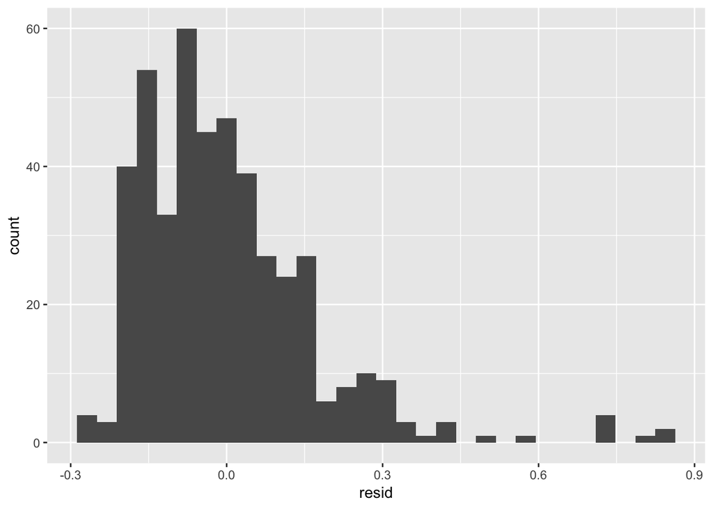

```r
ggplot(percent_curbing, aes(resid)) +
  geom_histogram()
```

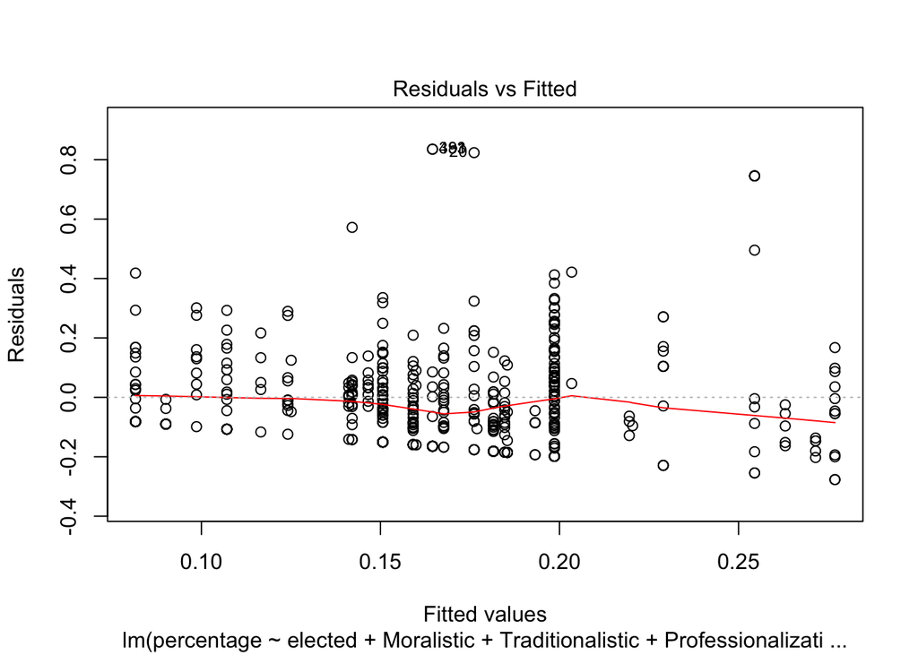

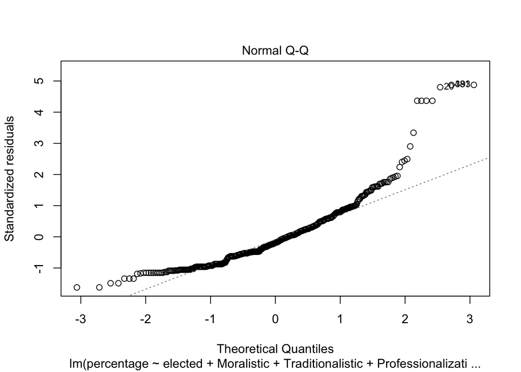

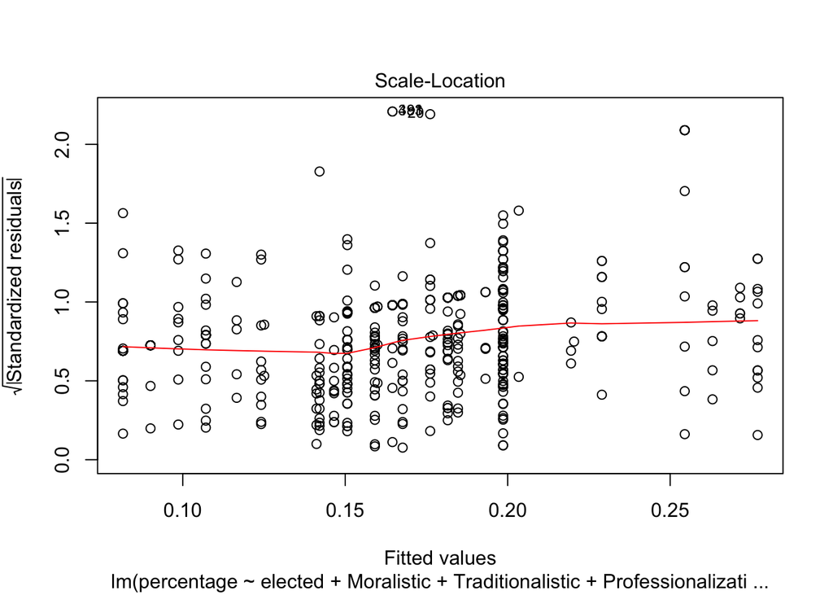

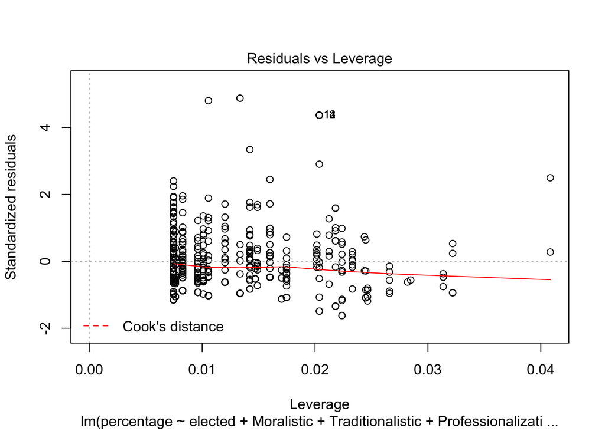

```r
plot(percent_md_no_id_1)
```

### Shorter years, but ideology

```r
percent_curbing2  <- percent_curbing2 %>%
  filter(!is.na(Elected)) %>%
  add_predictions(percent_md_6) %>%
  add_residuals(percent_md_6) %>%
  filter(!is.na(resid))
```

Checking normal distribution. It is pretty good, but there are some outliers at the far right. The mean of the residual is: -1.172305410^{-16} which is rather small.

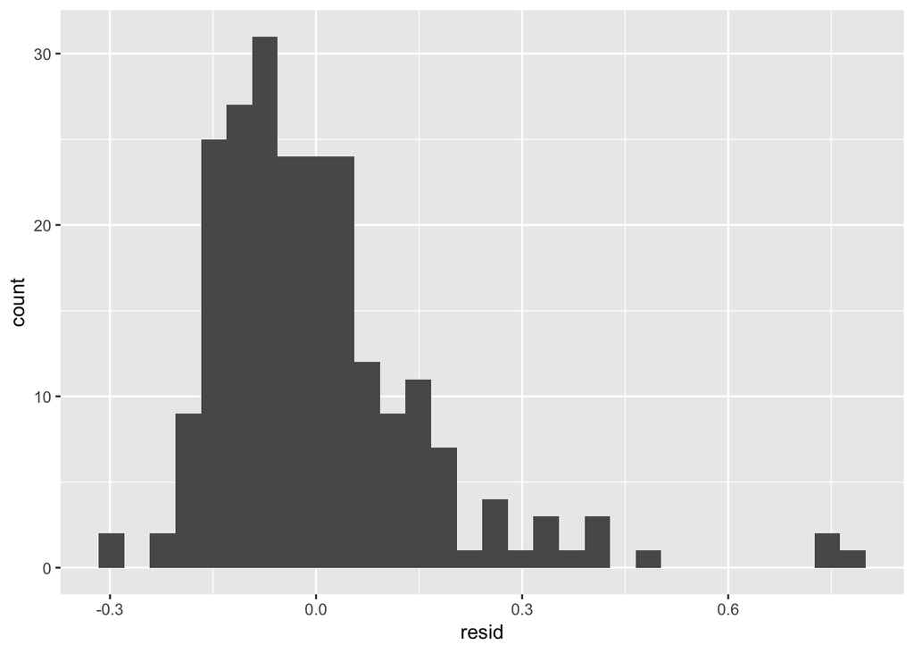

```r
ggplot(percent_curbing2, aes(resid)) +
  geom_histogram()
```

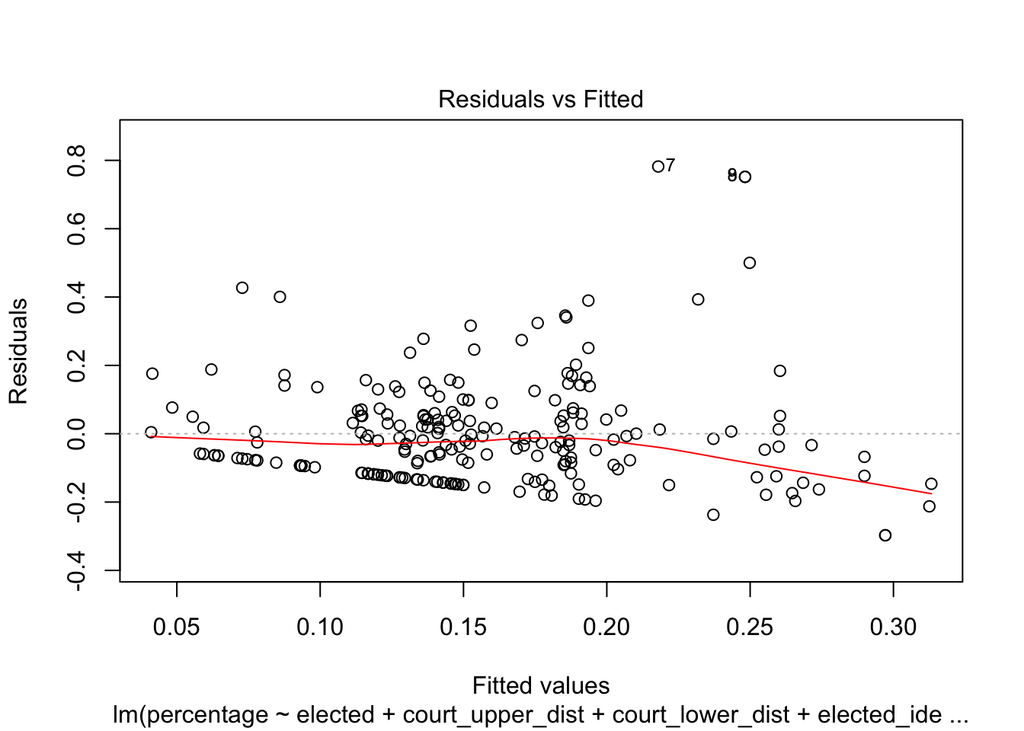

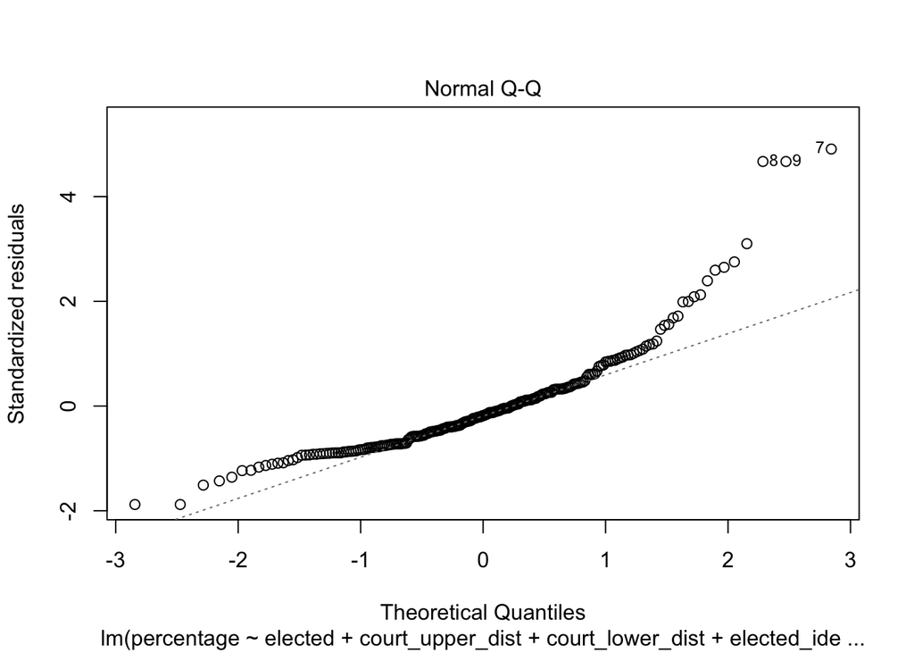

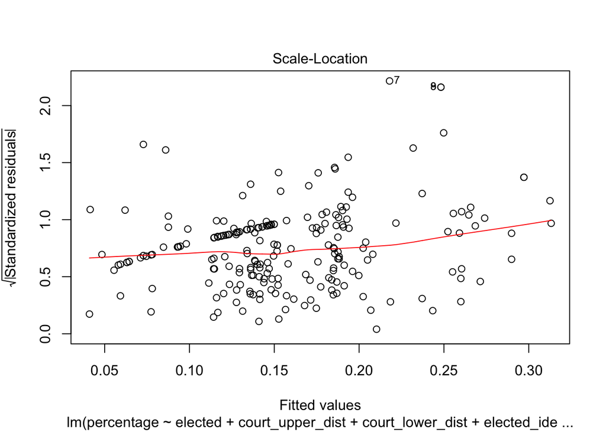

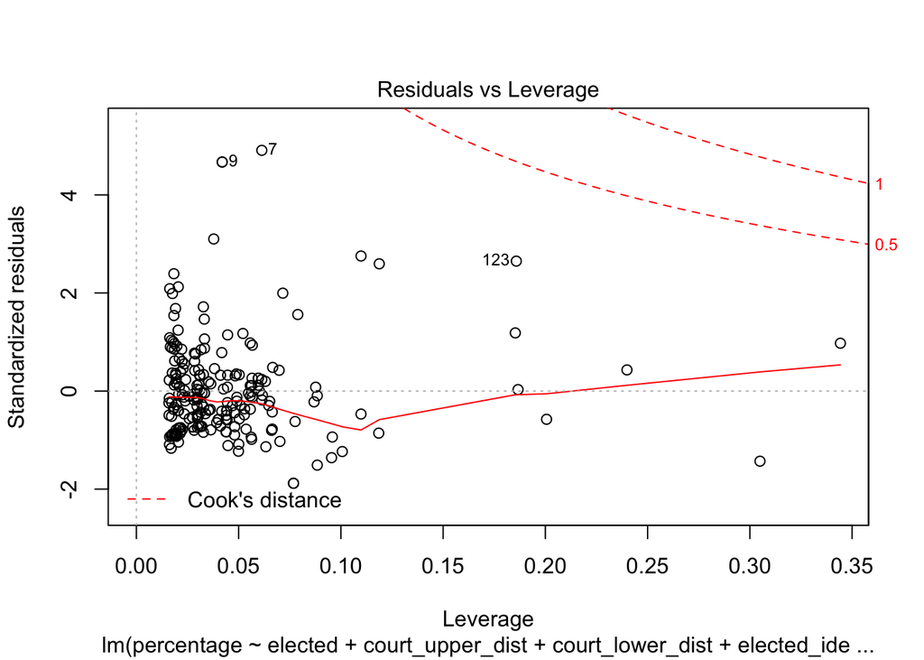

```r
plot(percent_md_6)
```

It does struggle on the outer edges of X.

### Concerns with the proportion DV

I am worried that the proportion of all court curbing legislation in one year for a given state is so small that changing the numerator by 1 will produce wild swings. Let’s check this out:

```r
d <- ggplot(percent_curbing) +
  geom_histogram(aes(x = percentage, y = ..density..)) +
  labs(x = "Proportion of Bills that Curb Courts")
```

The chart above shows the distribution of proportions. This is somewhat unsuripring in the distribution, but now lets look at the total number of legislation in a given year.

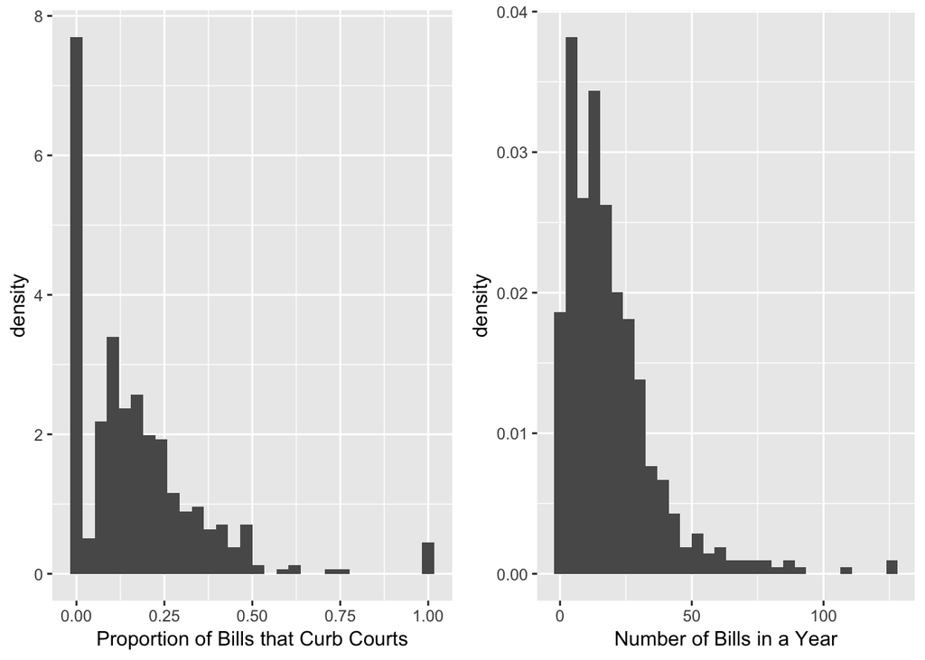

```r
bills_state_year <- gavelFull %>%
  group_by(Fullstate, Year) %>%
  count()

e <- ggplot(bills_state_year) +
  geom_histogram(aes(x = n, y = ..density..)) +
  labs(x = "Number of Bills in a Year")

gridExtra::grid.arrange(d, e, ncol = 2)
```